Back to Article

###### Article Notebook

Download Source

# Diaptera wings classification using Topological Data Analysis

Authors

Affiliation

Guilherme Vituri F. Pinto

Unesp

Sergio Ura

Northon

Published

April 14, 2025

Abstract

Keywords

Topological Data Analysis, Persistent homology

```
In [1]:
```

```julia
using TDAfly, TDAfly.Preprocessing, TDAfly.TDA, TDAfly.Analysis
using Images: mosaicview
using Plots: plot, display, heatmap
using PersistenceDiagrams
```

## 2 Methods

We load all wings into images

```
In [2]:
```

```julia
paths = readdir("images/processed", join = true)
species = basename.(paths) .|> (x -> replace(x, ".png" => ""))
individuals = map(species) do specie
  s = split(specie, " ")
  s[1][1] * "-" * s[2]
end
wings = load_wing.(paths)
Xs = map(image_to_r2, wings);
```

```
In [3]:
```

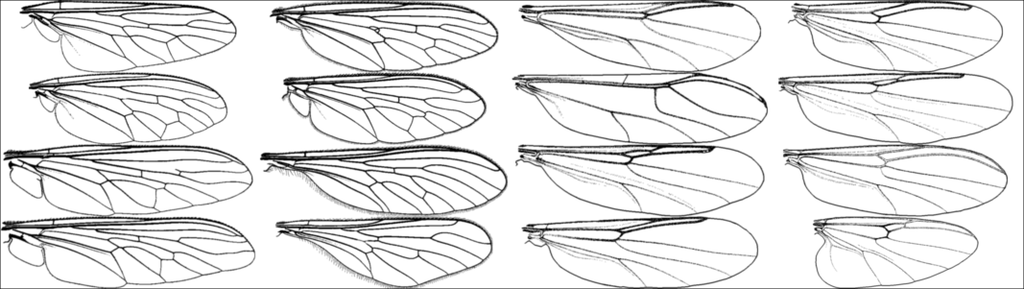

```julia
mosaicview(wings, ncol = 4, fillvalue=1)
```

### 2.1 Vietoris-Rips filtration

We select 500 points from each image using a farthest point sample method

```
In [4]:
```

```julia
samples = map(Xs) do X
  ids = farthest_points_sample(X, 500)
  X[ids]
end;
```

```
Progress:   0%|▏                                        |  ETA: 0:00:50Progress: 100%|█████████████████████████████████████████| Time: 0:00:00
```

We then calculate its persistence diagrams using the Vietoris-Rips filtration etc.

```
In [5]:
```

```julia
# get only the 1-dimensional PD
rips = rips_pd.(samples, cutoff = 5, threshold = 200) .|> last;
```

We create the 1-dimensional persistence image for each persistence diagram using 10x10 matrices

```
In [6]:
```

```julia
PI = PersistenceImage(rips, size = (10, 10))

images_rips = PI.(rips);
```

### 2.2 Examples

Below are some examples of 1-dimensional barcodes, its persistence image and the original wing that generated it. Note: we are plotting the barcode using the birth and persistence.

```
In [7]:
```

```julia
# plot some images to see the barcodes
map([1, 4, 8, 10, 15]) do i
  p = plot_wing_with_pd(rips[i], images_rips[i], samples[i], species[i])
  display(p)
end;
```

[figure not shown]

We now calculate the Euclidean distance between each persistence image (seen as a vector of $\mathbb{R}^{10x10}$) and plot its heatmap

```
In [8]:
```

```julia
D = pairwise_distance(images_rips);
```

```
In [9]:
```

```julia
plot_heatmap(D, individuals, "Distance matrix for Vietoris-Rips barcodes")
```

[figure not shown]

### 2.3 Persistence Homology Transform

Now we will create several filtrations based on points and lines, etc.

```
In [10]:
```

```julia
A = wings[1] |> image_to_array;
f = dist_to_point(0, 0)
Af = modify_array(A, f)
heatmap(Af)
```

[figure not shown]

```
In [11]:
```

```julia
point_pds = cubical_pd(Af, cutoff = 0.05)
plot_pd(point_pds)
```

[figure not shown]